# Double Robustness

CML Week 4

2026-09-22

## Schedule

1. Design-based causal inference & Monte Carlo simulation
2. Covariate adjustment
3. Balancing weights
4. **Double robustness, Double ML and TMLE**
5. Heterogeneous Treatment Effects
6. HTE II: Neural Networks
7. Off-policy evaluation and optimization
8. Experimental design
9. Panel data and the new diff-in-diff
10. Partial Identification
11. Response adaptation
12. Interference

## The big idea

[figure not shown]

- The edge from $A \to Y$ is the causal effect we want to measure
- The edge from $X \to Y$ is what we’re correcting for when we do covariate adjustment
- The edge from $X \to A$ is what we’re correcting for when we do balancing
- What if we simultaneously do **both**? How can we do that?

# (Bang and Robins 2005)

## Double robustness

**The core insight:** An estimator is doubly robust if it remains consistent when *either* (but not necessarily both):

1. **Outcome regression model** is correctly specified, *or*
2. **Treatment assignment model** (propensity score) is correctly specified

**Why this matters:**

- Model misspecification is inevitable in practice
- We get “two chances” to be right instead of one
- Combines the best features of:
  - **G-computation:** models the outcome regression $\mu(X) = E[Y \mid A=1, X]$
  - **Inverse probability weighting:** models the propensity score $e(X) = P(A=1 \mid X)$ and reweights

**Key theoretical result:** Under standard assumptions, DR estimators achieve the semiparametric efficiency bound when both models are correct.

## Setup and notation

- **Data:** $(A_i, X_i, Y_i)_{i=1}^n$, with $A_i \in \{0,1\}$ a sampling indicator: only see $Y_i$ when $A_i = 1$
- **Target:** $\psi = E[Y]$
- **Identification:** MAR, $Y \perp A \mid X$

**Two nuisance functions**, in last week’s notation, each with a parametric working model:

|  | Truth | Working model |
| --- | --- | --- |
| Propensity score | $e(X) = P(A = 1 \mid X)$ | $e_\alpha(X)$ |
| Outcome regression | $\mu(X) = E[Y \mid A = 1, X]$ | $\mu_{\beta,\phi}(X)$ |

*Bang & Robins write $\pi(X;\alpha)$, $e(X;\beta,\phi)$ and $\mu$. We write $e_\alpha(X)$, $\mu_{\beta,\phi}(X)$ and $\psi$.*

## The DR estimator

**Bang & Robins, linear case.** Three steps:

1. **Fit the propensity model:** $\hat{e}(X) = e_{\hat{\alpha}}(X)$
2. **Fit the outcome model with $\hat{e}^{-1}$ as an extra regressor,** by OLS among the observed ($A_i = 1$):
   $$\mu_{\beta,\phi}(X_i) = X_i^\top \beta + \phi\, \hat{e}(X_i)^{-1}, \qquad 0 = \sum_i A_i \begin{pmatrix} X_i \\ \hat{e}(X_i)^{-1} \end{pmatrix} \big(Y_i - \mu_{\beta,\phi}(X_i)\big)$$
   Call the fit $\hat{\mu} = \mu_{\hat{\beta},\hat{\phi}}$.
3. **Average the fitted values over everyone,** observed or not:
   $$\hat{\psi}_{dr} = \frac{1}{n} \sum_i \hat{\mu}(X_i)$$

Step 3 is just averaging over the model. All we did was add $\hat{e}^{-1}$ in step 2.

## Why is it DR? Step 0: rewrite the estimator

Shorthand: $\hat{e}_i = \hat{e}(X_i)$ and $\hat{\mu}_i = \hat{\mu}(X_i)$.

Truth: $e(X) = P(A=1 \mid X)$, $\mu(X) = E[Y \mid A=1, X]$, and $\psi = E[Y] = E[\mu(X)]$.

- $\hat{e}_i^{-1}$ is a **regressor** in the outcome fit, its normal equation holds in sample:
  $$\sum_i A_i\, \hat{e}_i^{-1}\, (Y_i - \hat{\mu}_i) = 0$$
- Add this zero to $\hat{\psi}_{dr}$ and it becomes a sum of two familiar pieces:
  $$\hat{\psi}_{dr} = \underbrace{\frac{1}{n}\sum_i \hat{\mu}_i}_{\text{G-computation}} \;+\; \underbrace{\frac{1}{n}\sum_i \frac{A_i}{\hat{e}_i}\,(Y_i - \hat{\mu}_i)}_{\text{IPW, applied to residuals}}$$
- This is the **augmented IPW** form. Plan: hold one model at its truth, let the other be anything, and take expectations term by term using **MAR** ($Y \perp A \mid X$) and **iterated expectations**.

## Why is it DR? Step 1: the outcome model is right

Suppose $\hat{\mu}_i \to \mu(X_i)$. Make no assumption about $\hat{e}$ beyond $\hat{e} > 0$.

**First term.** MAR lets us drop the conditioning on $A = 1$:
$$E[\mu(X)] = E\big[E[Y \mid A=1, X]\big] = E\big[E[Y \mid X]\big] = E[Y] = \psi$$

**Second term.** Condition on $X$; $\hat{e}(X)$ is then a constant and comes outside:
$$E\left[\frac{A}{\hat{e}(X)}\,(Y - \mu(X))\right] = E\left[\frac{1}{\hat{e}(X)}\; E\big[A\,(Y - \mu(X)) \mid X\big]\right]$$
and the inner expectation is zero because $A(Y - \mu)$ is only nonzero when $A = 1$, where $\mu$ is the conditional mean:
$$E\big[A\,(Y - \mu(X)) \mid X\big] = e(X)\; E\big[Y - \mu(X) \mid A=1, X\big] = e(X) \cdot 0 = 0$$

- The correction term vanishes for any $\hat{e}$: a wrong propensity model just reweights residuals that are already mean-zero given $X$. So $\hat{\psi}_{dr} \to \psi$; the correction only adds noise.

## Why is it DR? Step 2: the propensity score is right

Suppose $\hat{e}_i \to e(X_i)$, and let $\hat{\mu}_i \to \mu^*(X_i)$ for an arbitrary (wrong) $\mu^*$.

Regroup the two pieces by what multiplies $\mu^*$:
$$\hat{\psi}_{dr} = \frac{1}{n}\sum_i \frac{A_i\, Y_i}{e(X_i)} \;+\; \frac{1}{n}\sum_i \left(1 - \frac{A_i}{e(X_i)}\right) \mu^*(X_i)$$

**First term.** Horvitz–Thompson (last week). MAR splits $E[AY \mid X]$ into a product:
$$E\left[\frac{A\,Y}{e(X)}\right] = E\left[\frac{E[A \mid X]\; E[Y \mid X]}{e(X)}\right] = E\big[E[Y \mid X]\big] = \psi$$

**Second term.** Condition on $X$; only $A$ is random inside:
$$E\left[\left(1 - \frac{A}{e(X)}\right) \mu^*(X)\right] = E\left[\left(1 - \frac{E[A \mid X]}{e(X)}\right) \mu^*(X)\right] = E\big[0 \cdot \mu^*(X)\big] = 0$$

- The outcome model enters only through a term with mean exactly zero: it cannot bias, only change variance. Steps 1 and 2 are mirror images: when one model is right, the other’s term is inert.

## Why is it DR? Both at once: the bias is a product

Let both limits be wrong: $\hat{\mu} \to \mu^*$ and $\hat{e} \to e^*$. Taking expectations of the augmented form, with $\psi = E[\mu(X)]$:
$$E[\hat{\psi}_{dr}] - \psi = E[\mu^*(X)] + E\left[\frac{e(X)}{e^*(X)}\,\big(\mu(X) - \mu^*(X)\big)\right] - E[\mu(X)]$$

Collect the $\mu - \mu^*$ terms:
$$E[\hat{\psi}_{dr}] - \psi = E\left[\big(\mu(X) - \mu^*(X)\big)\;\frac{e(X) - e^*(X)}{e^*(X)}\right]$$

- **Either factor zero, bias zero.** Steps 1 and 2 in a single line.
- **Both a little wrong:** the bias is a product of two errors, which is smaller than either. This is the seed of double ML: rates multiply.
- **Both moderately wrong, with small $e^*$:** the product is not small, and the denominator makes it worse. This is Kang & Schafer’s cautionary tale.

## OLS is DR? Step 1: Frisch–Waugh–Lovell

Regress $Y$ on $A$ and $X$ (intercept in $X$); call the coefficient on $A$ $\hat{\tau}_{OLS}$. **Partial regression** purges $X$ from both variables first: $\tilde{A}_i = A_i - X_i^\top \hat{\gamma}$ and $\tilde{Y}_i = Y_i - X_i^\top \hat{\delta}$.

**FWL:** the multiple-regression coefficient is the regression of residual on residual,
$$\hat{\tau}_{OLS} = \frac{\sum_i \tilde{A}_i \tilde{Y}_i}{\sum_i \tilde{A}_i^2}$$
an exact in-sample identity.

**Two readings of the same formula:**

- $\hat{\tau}_{OLS} = \sum_i w_i \tilde{Y}_i$ with $w_i = \tilde{A}_i / \sum_j \tilde{A}_j^2$: a **weighting estimator**, and $\sum_i w_i X_i = 0$ is exact mean balance on $X$ (last week’s constraint with $f(X) = X$).
- $X_i^\top \hat{\gamma}$ is a fitted **linear probability model** for $P(A_i = 1 \mid X_i)$, so $\tilde{A}_i = A_i - \hat{e}^{\text{lin}}(X_i)$. OLS carries a propensity model inside it: linear in $X$, fit by least squares.

## OLS is DR? Step 2: two models inside one regression

One regression, two working models: **outcome** $E[Y \mid A, X] = \tau A + X^\top \beta$ and **implicit propensity** $E[A \mid X] = X^\top \gamma$.

**Route 1: outcome model right.** $Y_i = \tau A_i + X_i^\top\beta + \varepsilon_i$ with $E[\varepsilon_i \mid A_i, X_i] = 0$, so $\hat{\tau}_{OLS} \to \tau$. Textbook.

**Route 2: propensity model right, outcome model wrong.** Let $Y_i = \tau A_i + g(X_i) + \varepsilon_i$ with $g$ arbitrary. Substitute into FWL, using $\sum_i \tilde{A}_i A_i = \sum_i \tilde{A}_i^2$:
$$\hat{\tau}_{OLS} - \tau = \frac{\sum_i \tilde{A}_i\, g(X_i) + \sum_i \tilde{A}_i\, \varepsilon_i}{\sum_i \tilde{A}_i^2}$$
If $E[A \mid X] = X^\top\gamma$, then in the population $\tilde{A} = A - X^\top\gamma$ has $E[\tilde{A} \mid X] = 0$, so by iterated expectations $E[\tilde{A}\, g(X)] = E\big[E[\tilde{A} \mid X]\, g(X)\big] = 0$ for *every* $g$.

- The omitted nonlinearity is orthogonal to the residualised treatment, so $\hat{\tau}_{OLS} \to \tau$ with $E[Y \mid A, X]$ misspecified. Same structure as Bang & Robins Step 2.

## OLS is DR? Step 3: the heteroskedasticity catch

Route 2 assumed a constant $\tau$. Let effects vary, $\tau(X) = E[Y(1) - Y(0) \mid X]$, with only the propensity model right, so $\tilde{A} = A - e(X)$. Conditional on $X$:
$$E[\tilde{A}\, Y \mid X] = e(X)\big(1 - e(X)\big)\, \tau(X), \qquad E[\tilde{A}^2 \mid X] = e(X)\big(1 - e(X)\big)$$

$$\hat{\tau}_{OLS} \;\to\; \frac{E[\tilde{A}\, Y]}{E[\tilde{A}^2]} = \frac{E\big[e(X)\,(1 - e(X))\; \tau(X)\big]}{E\big[e(X)\,(1 - e(X))\big]}$$

- This is (Aronow and Samii 2016): a conditional-variance-weighted effect.
  - Units with $e(X)$ near $1/2$ count most.
  - The heteroskedasticity is in the **treatment**: $\text{Var}(A \mid X) = e(1-e)$.
- It equals the ATE when $\tau(X)$ is constant or uncorrelated with $e(X)(1-e(X))$.
  - Otherwise OLS is doubly robust for a *different estimand*.

**Punchline:** OLS is DR for a constant effect because it balances $X$ exactly in sample. Bang & Robins put $\hat{e}^{-1}$ into the outcome regression on purpose; OLS puts a linear $\hat{e}$ in by accident.

## Bang & Robins simulation results

**Setup:** Multiple data-generating processes with different model specifications

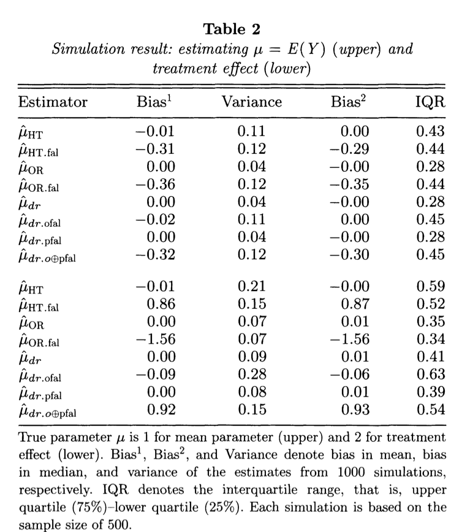

**The “double protection”:** DR gives you robustness against misspecification of either model, dramatically improving practical performance.

## What Bang & Robins opened up

**Insight:** We don’t need to get *one* model exactly right. We can hedge our bets.

**Key innovations:**

- Unified framework connecting outcome regression and IPW
- Formal double robustness theory
- Practical estimators that “just work” in many settings

**Issues:**

- Why should we expect to get even one model right?
  - Yes, two lottery tickets give you a better chance than one.
- How should we do all of this estimation flexibly?
  - Replace parametric models with ML, IPW with balancing weights?

## Open questions

1. **Machine learning integration:** What happens when we soup-up Frisch-Waugh-Lovell with machine learning?
   - *Motivates:* (Chernozhukov et al. 2018) on double/debiased ML
2. **Optimal bias-variance tradeoffs:** Can we do better than simple plug-in estimation? How do we target the parameter of interest more directly?
   - *Motivates:* (Schuler and Rose 2017) on targeted maximum likelihood estimation (TMLE), with more detail in (Van der Laan, Rose, et al. 2011).
3. **When do DR methods actually work?** Are there settings where all approaches fail catastrophically?
   - *Motivates:* (Kang and Schafer 2007) empirical comparison studies
4. **Modern theoretical foundations:** How do we unify these ideas with modern semiparametric theory and machine learning?
   - *Motivates:* (Kennedy 2022) comprehensive review

## More to read

| Paper | Why you’d read it |
| --- | --- |
| (Kennedy 2022) | The review that frames today: influence functions, and why “doubly robust” and “debiased” are one idea. Parts 1–3. |
| (Chernozhukov et al. 2018) | Double/debiased ML: Neyman-orthogonal scores plus cross-fitting make ML nuisance estimates safe to plug in. Parts 1–3. |
| (Schuler and Rose 2017); (Van der Laan, Rose, et al. 2011) | TMLE: fit an initial outcome model, then take one *targeting* step toward the parameter. The tutorial, and the book behind it (Ch. 4–6). |
| (Bruns-Smith et al. 2025) | Augmented balancing weights are a linear regression in disguise: last week’s methods and this week’s are one estimator. |
| (Chernozhukov et al. 2022); (Chernozhukov, Newey, and Singh 2022) | Automatic debiased ML: learn the Riesz representer directly, by neural net or forest, instead of a propensity score. In `EconML`. |
| (Kang and Schafer 2007) | The cautionary tale: every DR estimator does badly when both models are mildly wrong. |

# References

Aronow, P M, and Cyrus Samii. 2016. “Does Regression Produce Representative Estimates of Causal Effects?” *American Journal of Political Science* 60 (1): 250–67.

Bang, Heejung, and James M Robins. 2005. “Doubly Robust Estimation in Missing Data and Causal Inference Models.” *Biometrics* 61 (4): 962–73.

Bruns-Smith, David, Oliver Dukes, Avi Feller, and Elizabeth L Ogburn. 2025. “Augmented Balancing Weights as Linear Regression.” *Journal of the Royal Statistical Society: Series B* 88 (3): 699–723.

Chernozhukov, Victor, Denis Chetverikov, Mert Demirer, Esther Duflo, Christian Hansen, Whitney Newey, and James Robins. 2018. “Double/Debiased Machine Learning for Treatment and Structural Parameters.” *The Econometrics Journal* 21 (1): C1–68. https://doi.org/10.1111/ectj.12097.

Chernozhukov, Victor, Whitney K Newey, Vı́ctor Quintas-Martı́nez, and Vasilis Syrgkanis. 2022. “RieszNet and ForestRiesz: Automatic Debiased Machine Learning with Neural Nets and Random Forests.” In *International Conference on Machine Learning*, 3901–14. PMLR.

Chernozhukov, Victor, Whitney K Newey, and Rahul Singh. 2022. “Automatic Debiased Machine Learning of Causal and Structural Effects.” *Econometrica* 90 (3): 967–1027.

Kang, Joseph DY, and Joseph L Schafer. 2007. “Demystifying Double Robustness: A Comparison of Alternative Strategies for Estimating a Population Mean from Incomplete Data.” *Statistical Science* 22 (4): 523–39.

Kennedy, Edward H. 2022. “Semiparametric Doubly Robust Targeted Double Machine Learning: A Review.” https://arxiv.org/abs/2203.06469.

Schuler, Megan S., and Sherri Rose. 2017. “Targeted Maximum Likelihood Estimation for Causal Inference in Observational Studies.” *American Journal of Epidemiology* 185 (1): 65–73. https://doi.org/10.1093/aje/kww165.

Van der Laan, Mark J, Sherri Rose, et al. 2011. *Targeted Learning: Causal Inference for Observational and Experimental Data*. Vol. 4. Springer.